# My Capstone Project on Bike Ride

Chinonso

2025-01-03

# Setting up my r environment and Loading packages

```r
getwd()
```

```
## [1] "C:/Users/cexsa/Documents/Projects/R"
```

```r
library(tidyverse)
```

```r
library(ggplot2)
library(janitor)
library(lubridate)
library(readr)
library(skimr)
library(dplyr)
library(tidyr)
library(gt)
library(farver)
library(plotrix)
library(tinytex)
```

# setting directory

```
setwd("C:/Users/cexsa/Documents/R/Project/bike-trip-dataset")
```

# assigning and importing dataset

```r
dec_23 <- read.csv("202312-divvy-tripdata.csv")
jan_24 <- read.csv("202401-divvy-tripdata.csv")
feb_24 <- read.csv("202402-divvy-tripdata.csv")
mar_24 <- read.csv("202403-divvy-tripdata.csv")
apr_24 <- read.csv("202404-divvy-tripdata.csv")
may_24 <- read.csv("202405-divvy-tripdata.csv")
jun_24 <- read.csv("202406-divvy-tripdata.csv")
jul_24 <- read.csv("202407-divvy-tripdata.csv")
aug_24 <- read.csv("202408-divvy-tripdata.csv")
sept_24 <- read.csv("202409-divvy-tripdata.csv")
oct_24 <- read.csv("202410-divvy-tripdata.csv")
nov_24 <- read.csv("202411-divvy-tripdata.csv")
```

checking for uniformity in column names

```r
colnames(dec_23)
```

```
##  [1] "ride_id"            "rideable_type"      "started_at"
##  [4] "ended_at"           "start_station_name" "start_station_id"
##  [7] "end_station_name"   "end_station_id"     "start_lat"
## [10] "start_lng"          "end_lat"            "end_lng"
## [13] "member_casual"
```

```r
colnames(jan_24)
```

```
##  [1] "ride_id"            "rideable_type"      "started_at"
##  [4] "ended_at"           "start_station_name" "start_station_id"
##  [7] "end_station_name"   "end_station_id"     "start_lat"
## [10] "start_lng"          "end_lat"            "end_lng"
## [13] "member_casual"
```

```r
colnames(feb_24)
```

```
##  [1] "ride_id"            "rideable_type"      "started_at"
##  [4] "ended_at"           "start_station_name" "start_station_id"
##  [7] "end_station_name"   "end_station_id"     "start_lat"
## [10] "start_lng"          "end_lat"            "end_lng"
## [13] "member_casual"
```

```r
colnames(mar_24)
```

```
##  [1] "ride_id"            "rideable_type"      "started_at"
##  [4] "ended_at"           "start_station_name" "start_station_id"
##  [7] "end_station_name"   "end_station_id"     "start_lat"
## [10] "start_lng"          "end_lat"            "end_lng"
## [13] "member_casual"
```

```r
colnames(apr_24)
```

```
##  [1] "ride_id"            "rideable_type"      "started_at"
##  [4] "ended_at"           "start_station_name" "start_station_id"
##  [7] "end_station_name"   "end_station_id"     "start_lat"
## [10] "start_lng"          "end_lat"            "end_lng"
## [13] "member_casual"
```

```r
colnames(may_24)
```

```
##  [1] "ride_id"            "rideable_type"      "started_at"
##  [4] "ended_at"           "start_station_name" "start_station_id"
##  [7] "end_station_name"   "end_station_id"     "start_lat"
## [10] "start_lng"          "end_lat"            "end_lng"
## [13] "member_casual"
```

```r
colnames(jun_24)
```

```
##  [1] "ride_id"            "rideable_type"      "started_at"
##  [4] "ended_at"           "start_station_name" "start_station_id"
##  [7] "end_station_name"   "end_station_id"     "start_lat"
## [10] "start_lng"          "end_lat"            "end_lng"
## [13] "member_casual"
```

```r
colnames(jul_24)
```

```
##  [1] "ride_id"            "rideable_type"      "started_at"
##  [4] "ended_at"           "start_station_name" "start_station_id"
##  [7] "end_station_name"   "end_station_id"     "start_lat"
## [10] "start_lng"          "end_lat"            "end_lng"
## [13] "member_casual"
```

```r
colnames(aug_24)
```

```
##  [1] "ride_id"            "rideable_type"      "started_at"
##  [4] "ended_at"           "start_station_name" "start_station_id"
##  [7] "end_station_name"   "end_station_id"     "start_lat"
## [10] "start_lng"          "end_lat"            "end_lng"
## [13] "member_casual"
```

```r
colnames(sept_24)
```

```
##  [1] "ride_id"            "rideable_type"      "started_at"
##  [4] "ended_at"           "start_station_name" "start_station_id"
##  [7] "end_station_name"   "end_station_id"     "start_lat"
## [10] "start_lng"          "end_lat"            "end_lng"
## [13] "member_casual"
```

```r
colnames(oct_24)
```

```
##  [1] "ride_id"            "rideable_type"      "started_at"
##  [4] "ended_at"           "start_station_name" "start_station_id"
##  [7] "end_station_name"   "end_station_id"     "start_lat"
## [10] "start_lng"          "end_lat"            "end_lng"
## [13] "member_casual"
```

```r
colnames(nov_24)
```

```
##  [1] "ride_id"            "rideable_type"      "started_at"
##  [4] "ended_at"           "start_station_name" "start_station_id"
##  [7] "end_station_name"   "end_station_id"     "start_lat"
## [10] "start_lng"          "end_lat"            "end_lng"
## [13] "member_casual"
```

# merging all the data set

```r
bike_share <- rbind(dec_23, jan_24, feb_24, mar_24, apr_24, may_24, jun_24, jul_24, aug_24, sept_24, oct_24, nov_24)
```

```r
bike_share <- janitor::remove_empty(bike_share,which=c("cols"))
bike_share <- janitor::remove_empty(bike_share,which = c("rows"))
```

```r
bike_share$ymd <- as.Date(bike_share$started_at)
bike_share$started_at <-lubridate::ymd_hms(bike_share$started_at)
bike_share$ended_at <- lubridate::ymd_hms(bike_share$ended_at)
```

```r
bike_share$start_hour <- lubridate::hour(bike_share$started_at)
bike_share$ended_hour <- lubridate::hour(bike_share$ended_at)
```

```r
bike_share$Hours <- difftime(bike_share$ended_at, bike_share$started_at, units=c("hours"))
bike_share$minutes <- difftime(bike_share$ended_at, bike_share$started_at, units=c("mins"))
bike_share1 <- bike_share %>% filter(Hours>0)
```

```r
bike_share1 <- bike_share %>% filter(Hours>0) %>% drop_na()
```

#cleaning reducted the rows from 5906269 to 5898151

#eliminating some of the frames

```r
names(df)
```

# Load necessary library

```r
library(lubridate)
```

# Check the current format of your data

```r
head(bike_share$started_at)
```

```
## [1] "2023-12-02 18:44:01 UTC" "2023-12-02 18:48:19 UTC"
## [3] "2023-12-24 01:56:32 UTC" "2023-12-24 10:58:12 UTC"
## [5] "2023-12-24 12:43:16 UTC" "2023-12-24 13:59:57 UTC"
```

```r
head(bike_share$ended_at)
```

```
## [1] "2023-12-02 18:47:51 UTC" "2023-12-02 18:54:48 UTC"
## [3] "2023-12-24 02:04:09 UTC" "2023-12-24 11:03:04 UTC"
## [5] "2023-12-24 12:44:57 UTC" "2023-12-24 14:10:57 UTC"
```

# Convert ‘started_at’ and ‘ended_at’ columns to POSIXct

```r
bike_share1$started_at <- as.POSIXct(bike_share1$started_at, format = "%y/%m/%d %H:%M", tz = "UTC")
bike_share1$ended_at <- as.POSIXct(bike_share1$ended_at, format = "%y/%m/%d %H:%M", tz = "UTC")
```

# Extracting started ride date and time

```r
bike_share1$started_ride_date <- format(bike_share1$started_at, "%Y-%m-%d")

bike_share1$started_ride_time <- format(bike_share1$started_at, "%H:%M:%S")
```

#Extracting bike ride ended date and time

```r
bike_share1$ended_ride_date <- format(bike_share1$ended_at, "%Y-%m-%d")

bike_share1$ended_ride_time <- format(bike_share1$ended_at, "%H:%M:%S")
```

# Calculate ride length in seconds

```r
bike_share1$ride_length <- difftime(bike_share1$ended_at, bike_share1$started_at, units = "secs")
```

# ‘start_hour’

```r
bike_share1$start_hour <- format(as.POSIXct(bike_share1$started_at), "%H")
```

#Extracting date component for ‘year’, ‘month’, & ‘weekday’

```r
bike_share2 <- bike_share1 %>%
  mutate(year = lubridate::year(started_at),
         month = lubridate::month(started_at, label = TRUE), # month  "abbr"
         weekday = lubridate::wday(started_at, label = TRUE)) # day of week
```

# overview of dataset

```r
glimpse(bike_share2) #glimpse of dataset
```

```
## Rows: 5,898,151
## Columns: 26
## $ ride_id            <chr> "C9BD54F578F57246", "CDBD92F067FA620E", "ABC0858E52…
## $ rideable_type      <chr> "electric_bike", "electric_bike", "electric_bike", …
## $ started_at         <dttm> 2023-12-02 18:44:01, 2023-12-02 18:48:19, 2023-12-…
## $ ended_at           <dttm> 2023-12-02 18:47:51, 2023-12-02 18:54:48, 2023-12-…
## $ start_station_name <chr> "", "", "", "", "", "", "", "", "", "", "", "", "",…
## $ start_station_id   <chr> "", "", "", "", "", "", "", "", "", "", "", "", "",…
## $ end_station_name   <chr> "", "", "", "", "", "", "", "", "", "", "", "", "",…
## $ end_station_id     <chr> "", "", "", "", "", "", "", "", "", "", "", "", "",…
## $ start_lat          <dbl> 41.92, 41.92, 41.89, 41.95, 41.92, 41.91, 41.99, 42…
## $ start_lng          <dbl> -87.66, -87.66, -87.62, -87.65, -87.64, -87.63, -87…
## $ end_lat            <dbl> 41.92, 41.89, 41.90, 41.94, 41.93, 41.88, 42.00, 41…
## $ end_lng            <dbl> -87.66, -87.64, -87.64, -87.65, -87.64, -87.65, -87…
## $ member_casual      <chr> "member", "member", "member", "member", "member", "…
## $ ymd                <date> 2023-12-02, 2023-12-02, 2023-12-24, 2023-12-24, 20…
## $ start_hour         <chr> "18", "18", "01", "10", "12", "13", "09", "08", "18…
## $ ended_hour         <int> 18, 18, 2, 11, 12, 14, 9, 8, 18, 6, 19, 19, 19, 0, …
## $ Hours              <drtn> 0.063888889 hours, 0.108055556 hours, 0.126944444 …
## $ minutes            <drtn> 3.8333333 mins, 6.4833333 mins, 7.6166667 mins, 4.…
## $ started_ride_date  <chr> "2023-12-02", "2023-12-02", "2023-12-24", "2023-12-…
## $ started_ride_time  <chr> "18:44:01", "18:48:19", "01:56:32", "10:58:12", "12…
## $ ended_ride_date    <chr> "2023-12-02", "2023-12-02", "2023-12-24", "2023-12-…
## $ ended_ride_time    <chr> "18:47:51", "18:54:48", "02:04:09", "11:03:04", "12…
## $ ride_length        <drtn> 230 secs, 389 secs, 457 secs, 292 secs, 101 secs, …
## $ year               <dbl> 2023, 2023, 2023, 2023, 2023, 2023, 2023, 2023, 202…
## $ month              <ord> Dec, Dec, Dec, Dec, Dec, Dec, Dec, Dec, Dec, Dec, D…
## $ weekday            <ord> Sat, Sat, Sun, Sun, Sun, Sun, Sun, Sun, Mon, Sun, S…
```

```r
bike_share_clean <- bike_share2 %>%
  select(-ymd, -Hours, -minutes, -ended_hour)
```

```r
glimpse(bike_share_clean) #glimpse of dataset
```

```
## Rows: 5,898,151
## Columns: 22
## $ ride_id            <chr> "C9BD54F578F57246", "CDBD92F067FA620E", "ABC0858E52…
## $ rideable_type      <chr> "electric_bike", "electric_bike", "electric_bike", …
## $ started_at         <dttm> 2023-12-02 18:44:01, 2023-12-02 18:48:19, 2023-12-…
## $ ended_at           <dttm> 2023-12-02 18:47:51, 2023-12-02 18:54:48, 2023-12-…
## $ start_station_name <chr> "", "", "", "", "", "", "", "", "", "", "", "", "",…
## $ start_station_id   <chr> "", "", "", "", "", "", "", "", "", "", "", "", "",…
## $ end_station_name   <chr> "", "", "", "", "", "", "", "", "", "", "", "", "",…
## $ end_station_id     <chr> "", "", "", "", "", "", "", "", "", "", "", "", "",…
## $ start_lat          <dbl> 41.92, 41.92, 41.89, 41.95, 41.92, 41.91, 41.99, 42…
## $ start_lng          <dbl> -87.66, -87.66, -87.62, -87.65, -87.64, -87.63, -87…
## $ end_lat            <dbl> 41.92, 41.89, 41.90, 41.94, 41.93, 41.88, 42.00, 41…
## $ end_lng            <dbl> -87.66, -87.64, -87.64, -87.65, -87.64, -87.65, -87…
## $ member_casual      <chr> "member", "member", "member", "member", "member", "…
## $ start_hour         <chr> "18", "18", "01", "10", "12", "13", "09", "08", "18…
## $ started_ride_date  <chr> "2023-12-02", "2023-12-02", "2023-12-24", "2023-12-…
## $ started_ride_time  <chr> "18:44:01", "18:48:19", "01:56:32", "10:58:12", "12…
## $ ended_ride_date    <chr> "2023-12-02", "2023-12-02", "2023-12-24", "2023-12-…
## $ ended_ride_time    <chr> "18:47:51", "18:54:48", "02:04:09", "11:03:04", "12…
## $ ride_length        <drtn> 230 secs, 389 secs, 457 secs, 292 secs, 101 secs, …
## $ year               <dbl> 2023, 2023, 2023, 2023, 2023, 2023, 2023, 2023, 202…
## $ month              <ord> Dec, Dec, Dec, Dec, Dec, Dec, Dec, Dec, Dec, Dec, D…
## $ weekday            <ord> Sat, Sat, Sun, Sun, Sun, Sun, Sun, Sun, Mon, Sun, S…
```

```r
bike_share_clean %>%
  select(member_casual, ride_length) %>%
  group_by(member_casual) %>%
  dplyr::summarize(min_ride_length = min(ride_length), max_ride_length = max(ride_length)) %>%
  ungroup()
```

```
## # A tibble: 2 × 3
##   member_casual min_ride_length max_ride_length
##   <chr>         <drtn>          <drtn>
## 1 casual        0.05099988 secs 90562 secs
## 2 member        0.03900003 secs 89996 secs
```

```r
bike_clean1 <- bike_share_clean %>%
  filter(ride_length >= 60 & ride_length < 86400)
```

```r
nrow(bike_clean1)
```

```
## [1] 5765590
```

# converting ‘ride_length’ to numeric before analyzing

```r
is.factor(bike_clean1$ride_length) #FLASE
```

```
## [1] FALSE
```

```r
bike_clean1$ride_length <- as.numeric(as.character(bike_clean1$ride_length))
```

```r
is.numeric(bike_clean1$ride_length) #TRUE
```

```
## [1] TRUE
```

#ordering by ‘started_at’ in Ascending order

```r
bike_Final_clean <-  arrange(bike_clean1, started_at)
print(bike_Final_clean)
```

[output not shown]

[output cut: 27262 more lines]

# Dataset Overview

```r
bike_Final_clean %>% head(10)
```

```
##             ride_id rideable_type          started_at            ended_at
## 1  466F415078C6EF10 electric_bike 2023-12-01 00:00:03 2023-12-01 00:06:09
## 2  9FA7BD2646C3A238  classic_bike 2023-12-01 00:00:20 2023-12-01 00:07:25
## 3  C2514CFD2DF51C1C electric_bike 2023-12-01 00:00:34 2023-12-01 00:16:28
## 4  F5362D06B7B66CB7  classic_bike 2023-12-01 00:01:09 2023-12-01 00:10:13
## 5  D3B94A73D0938E55  classic_bike 2023-12-01 00:01:46 2023-12-01 00:14:21
## 6  45C707F568002396  classic_bike 2023-12-01 00:02:00 2023-12-01 00:05:59
## 7  8F477590CB57F538 electric_bike 2023-12-01 00:02:03 2023-12-01 00:18:12
## 8  1008B3FBE9FF1A6F  classic_bike 2023-12-01 00:02:28 2023-12-01 00:14:26
## 9  90D67694C970CABF  classic_bike 2023-12-01 00:02:29 2023-12-01 00:22:00
## 10 CAAE0CD9DD0D38DE  classic_bike 2023-12-01 00:02:44 2023-12-01 00:07:01
##                start_station_name start_station_id           end_station_name
## 1                                                        Federal St & Polk St
## 2      Franklin St & Jackson Blvd     TA1305000025        Wabash Ave & 9th St
## 3
```

[output cut: 40 more lines]

##statistical summary of trip duration

```r
summary(bike_Final_clean$ride_length)
```

```
##    Min. 1st Qu.  Median    Mean 3rd Qu.    Max.
##    60.0   347.0   595.5   943.5  1047.8 86390.0
```

```r
bike_Final_clean %>%
    group_by(member_casual) %>%
    summarize(minmum_ride_length = min(ride_length),
              maximum_ride_length = max(ride_length),
              average_ride_length = mean(ride_length),
              median_ride_length = median(ride_length))
```

```
## # A tibble: 2 × 5
##   member_casual minmum_ride_length maximum_ride_length average_ride_length
##   <chr>                      <dbl>               <dbl>               <dbl>
## 1 casual                        60              86390                1292.
## 2 member                        60              86389.                745.
## # ℹ 1 more variable: median_ride_length <dbl>
```

#yearly percentage of casual Vs. member rides

```r
bike_Final_clean %>%
  group_by(member_casual) %>%
  summarise("numbers of rides" = n(), perc = n()/nrow(bike_Final_clean) *100)
```

```
## # A tibble: 2 × 3
##   member_casual `numbers of rides`  perc
##   <chr>                      <int> <dbl>
## 1 casual                   2093218  36.3
## 2 member                   3672372  63.7
```

#Create data for the graph

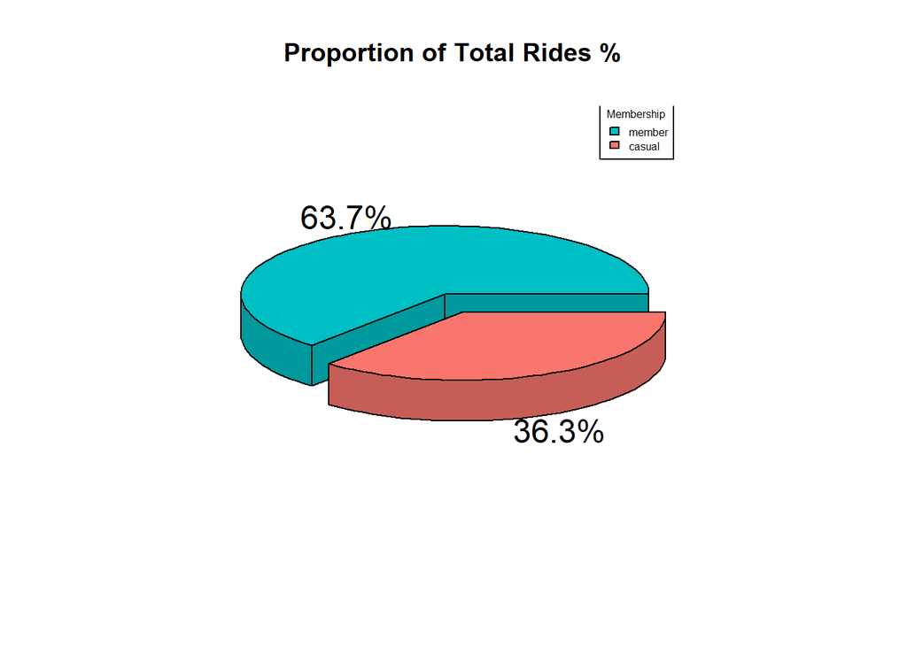

```r
x <-  c(3672372, 2093218)
piepercent <- paste0(round(x/sum(x)*100, 1), "%")
labels <-  c("member", "casual")
color <- c("#00BFC4","#F8766D")
# Plot the chart.
pie3D(x, labels = piepercent, explode =0.1, radius = 1,
  main = "Proportion of Total Rides %", col = color)
  legend(title = "Membership", "topright", c("member", "casual"),
  cex = 0.5, fill = color)
```

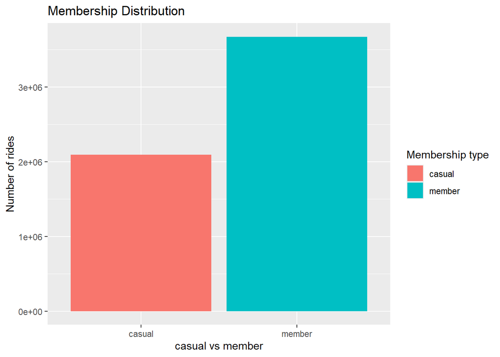

```r
bike_Final_clean %>%
  group_by(member_casual) %>%
  ggplot(aes(x=member_casual, fill = member_casual))+
  labs(title= "Membership Distribution", y= "Number of rides", x="casual vs member", fill="Membership type") +
  geom_bar(position='dodge')
```

#An analysis of the rides frequency over a period of 12 months to gain precise insights that will guide my approach to encourage casual members to transition into full-fledged annual members.

#Calculating rides per start_hour & Average

```r
bike_Final_clean %>%
  group_by(start_hour, member_casual) %>%
  summarize(ride_numbers = n(), .groups = 'drop', Average_duration = mean(ride_length))
```

```
## # A tibble: 48 × 4
##    start_hour member_casual ride_numbers Average_duration
##    <chr>      <chr>                <int>            <dbl>
##  1 00         casual               34172            1107.
##  2 00         member               32380             691.
##  3 01         casual               22806            1109.
##  4 01         member               19866             706.
##  5 02         casual               14105            1079.
##  6 02         member               11186             702.
##  7 03         casual                7811            1129.
##  8 03         member                7691             709.
##  9 04         casual                6117             979.
## 10 04         member                8611             727.
## # ℹ 38 more rows
```

# Visualization of rides at early hours

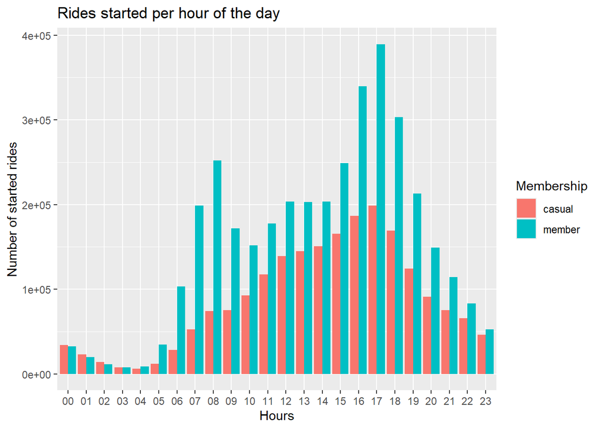

```r
 bike_Final_clean%>%
  group_by(start_hour, member_casual) %>%
  summarize(ride_numbers = n(), .groups = 'drop', Average_duration = mean(ride_length)) %>%
  ggplot(aes(x=start_hour, y=ride_numbers, fill= member_casual)) +
  geom_col(position = "dodge") +
  labs(title = "Rides started per hour of the day", x="Hours", y="Number of started rides", fill="Membership")
```

#Calculating rides per week

```r
bike_Final_clean %>%
  group_by(member_casual, weekday) %>%
  summarize(Number_Rides = n(),  .groups = 'drop', Average_rides = mean(ride_length)) %>%
  arrange(weekday)
```

```
## # A tibble: 14 × 4
##    member_casual weekday Number_Rides Average_rides
##    <chr>         <ord>          <int>         <dbl>
##  1 casual        Sun           358156         1496.
##  2 member        Sun           410870          827.
##  3 casual        Mon           243883         1253.
##  4 member        Mon           519409          712.
##  5 casual        Tue           225079         1112.
##  6 member        Tue           558355          713.
##  7 casual        Wed           263330         1143.
##  8 member        Wed           606871          725.
##  9 casual        Thu           259676         1120.
## 10 member        Thu           571274          714.
## 11 casual        Fri           310375         1246.
## 12 member        Fri           528305          727.
## 13 casual        Sat           432719         1468.
## 14 member        Sat           477288          827.
```

# Visualization of rides weekly

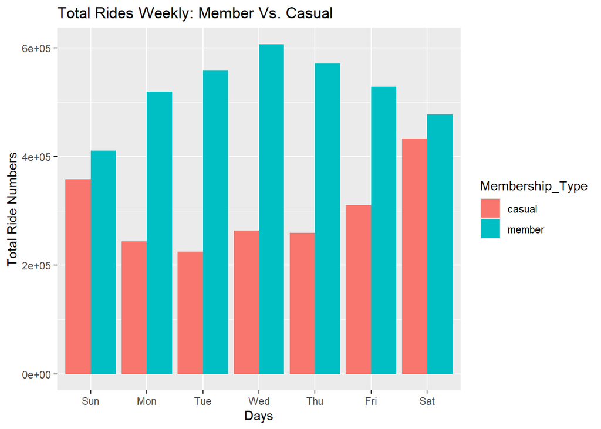

```r
bike_Final_clean %>%
  group_by(member_casual, weekday) %>%
  summarize(Number_Rides = n(),  .groups = 'drop', Average_rides = mean(ride_length)) %>%
  arrange(weekday) %>%
  ggplot(aes(x=weekday, y=Number_Rides, fill=member_casual))+
  geom_col(position='dodge')+
  labs(title = "Total Rides Weekly: Member Vs. Casual", x="Days", y="Total Ride Numbers", fill="Membership_Type")
```

#With this output showing total ride numbers, we can say that members its most likely that members uses the bike to go to work as the number of rides are more on weekdays with Wednesday recording the highest number. While casuals uses it more on weekends.

# Visualization of average weekly rides

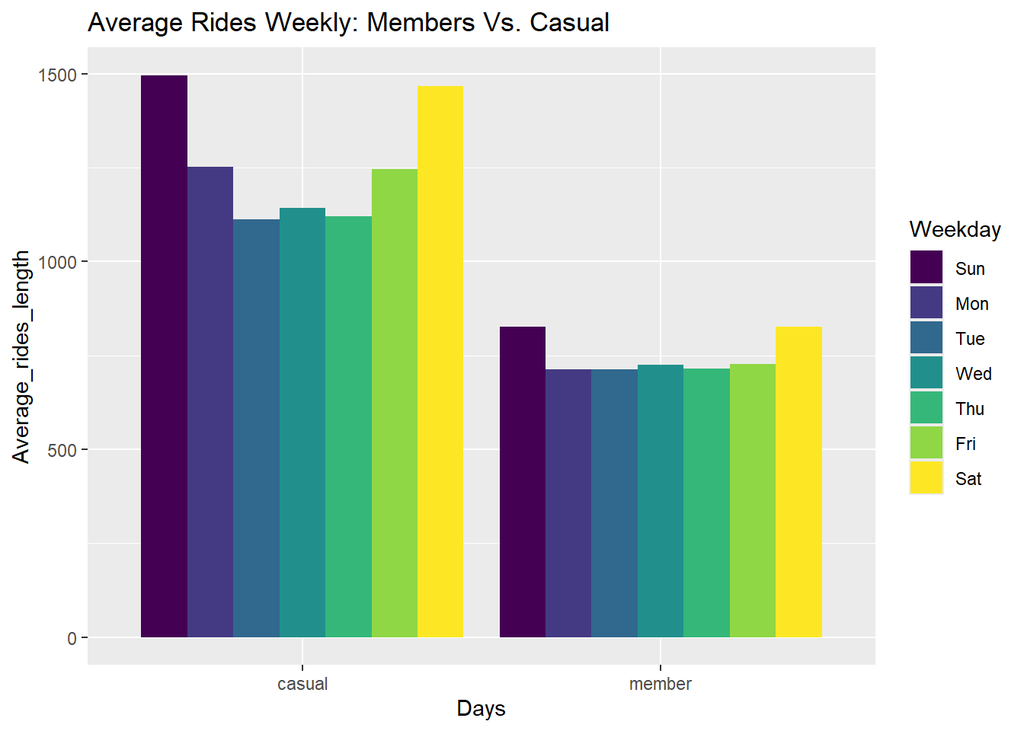

```r
bike_Final_clean %>%
  group_by(member_casual, weekday) %>%
  summarize(Number_Rides = n(),  .groups = 'drop', Average_rides = mean(ride_length)) %>%
  arrange(weekday) %>%
  ggplot(aes(x=member_casual, y=Average_rides, fill=weekday))+
  geom_bar(position='Dodge', stat='identity')+
  labs(title = "Average Rides Weekly: Members Vs. Casual", x="Days", y="Average_rides_length", fill="Weekday")
```

#Average ride length shows that Causal riders have a longer ride length all through the week recording highest ride length on weekends, Saturday and Sunday.

# Calculating rides per month

# Properly factorize the ‘month’ column

```r
library(dplyr)
library(lubridate)

# Ensure 'started_at' is in datetime format
bike_Final_clean$started_at <- as.POSIXct(bike_Final_clean$started_at, format = "%Y-%m-%d %H:%M:%S")

# Extract the month abbreviation in lowercase
bike_Final_clean$month <- tolower(format(bike_Final_clean$started_at, "%b"))

# Correctly factorize the 'month' column
bike_Final_clean$month <- factor(bike_Final_clean$month,
                                 levels = c("dec", "jan", "feb", "mar", "apr", "may", "jun",
                                            "jul", "aug", "sep", "oct", "nov"))

# Group, summarize, and arrange the data
bike_month <- bike_Final_clean %>%
  group_by(member_casual, month) %>%
  summarize(
    ride_numbers = n(),
    Average_duration = mean(ride_length, na.rm = TRUE), # Ignore NA values in calculations
    .groups = 'drop'
  ) %>%
  arrange(match(month, levels(bike_Final_clean$month)))

# Display the summary
print(bike_month)
```

```
## # A tibble: 24 × 4
##    member_casual month ride_numbers Average_duration
##    <chr>         <fct>        <int>            <dbl>
##  1 casual        dec          50403             897.
##  2 member        dec         168644             659.
##  3 casual        jan          23647             842.
##  4 member        jan         116561             698.
##  5 casual        feb          46019            1107.
##  6 member        feb         172796             715.
##  7 casual        mar          80317            1202.
##  8 member        mar         214367             685.
##  9 casual        apr         127599            1324.
## 10 member        apr         276714             723.
## # ℹ 14 more rows
```

```r
str(bike_month)
```

```
## tibble [24 × 4] (S3: tbl_df/tbl/data.frame)
##  $ member_casual   : chr [1:24] "casual" "member" "casual" "member" ...
##  $ month           : Factor w/ 12 levels "dec","jan","feb",..: 1 1 2 2 3 3 4 4 5 5 ...
##  $ ride_numbers    : int [1:24] 50403 168644 23647 116561 46019 172796 80317 214367 127599 276714 ...
##  $ Average_duration: num [1:24] 897 659 842 698 1107 ...
```

```r
bike_month <- bike_Final_clean %>%
  select(member_casual, month, weekday, ride_length) # Include all necessary columns
```

```r
bike_summary <- bike_month %>%
  group_by(member_casual, month) %>%
  summarize(
    ride_numbers = n(),
    Average_duration = mean(ride_length, na.rm = TRUE),
    .groups = 'drop'
  ) %>%
  arrange(match(month, c("dec", "jan", "feb", "mar", "apr", "may", "jun", "jul", "aug", "sept", "oct", "nov")))
```

```r
print(bike_summary)
```

```
## # A tibble: 24 × 4
##    member_casual month ride_numbers Average_duration
##    <chr>         <fct>        <int>            <dbl>
##  1 casual        dec          50403             897.
##  2 member        dec         168644             659.
##  3 casual        jan          23647             842.
##  4 member        jan         116561             698.
##  5 casual        feb          46019            1107.
##  6 member        feb         172796             715.
##  7 casual        mar          80317            1202.
##  8 member        mar         214367             685.
##  9 casual        apr         127599            1324.
## 10 member        apr         276714             723.
## # ℹ 14 more rows
```

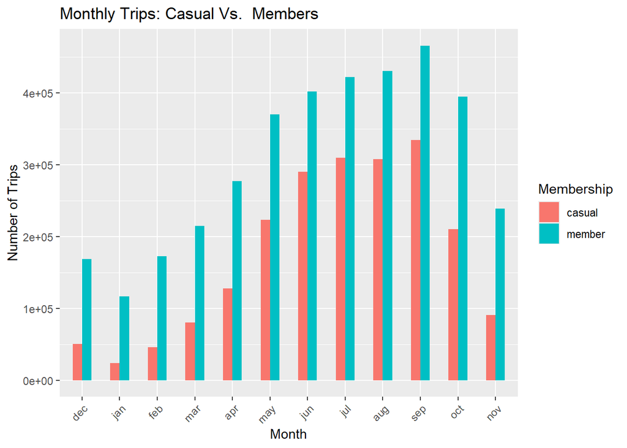

```r
ggplot(bike_summary, aes(x = month, y = ride_numbers, fill = member_casual)) +
  geom_col(position = position_dodge(width = 0.5), width = 0.5) +
  theme(axis.text.x = element_text(angle = 45, hjust = 1)) +
  labs(title = "Monthly Trips: Casual Vs.  Members",
       x = "Month",
       y = "Number of Trips",
       fill = "Membership")
```

#It is observed that in warmer months (June, July, August, September) there are more rides for both members and casuals. There is a sharp drop in rides for the month of December, January, February which is most likely to be due to winter season.

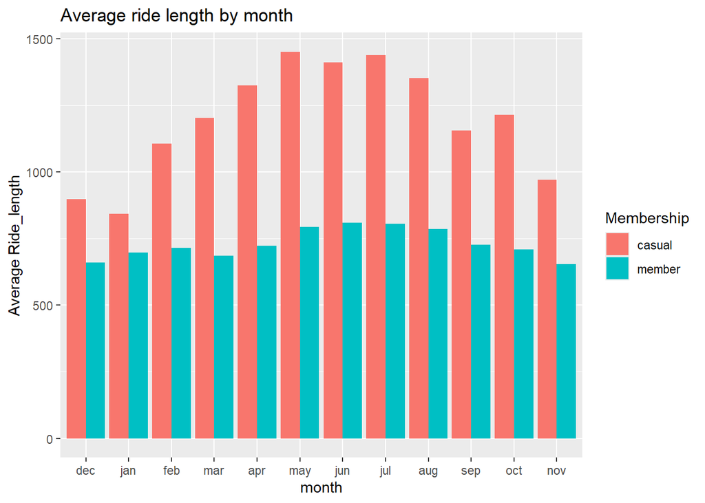

```r
bike_Final_clean %>%
  group_by(member_casual, month) %>%
  summarize(ride_numbers = n(), .groups = 'drop', Average_duration = mean(ride_length)) %>%
  arrange(month) %>%
  ggplot(aes(x=month, y=Average_duration, fill= member_casual)) +
  geom_col(position = 'dodge') +
  labs(title = "Average ride length by month", x="month", y="Average Ride_length", fill="Membership")
```

#Members are having an average ride length of <1000 secs throughout the year. While casual riders average ride length is between 750 - 1500 secs throughout the year. But in the month of may and July average ride length is higher.

```r
bike_Final_clean %>%
  group_by(member_casual, rideable_type) %>%
  summarise(total=n(), .groups = 'drop', perc =round(n()/nrow(bike_Final_clean)*100, 1)) %>%
  arrange(rideable_type)
```

```
## # A tibble: 6 × 4
##   member_casual rideable_type      total  perc
##   <chr>         <chr>              <int> <dbl>
## 1 casual        classic_bike      972093  16.9
## 2 member        classic_bike     1775012  30.8
## 3 casual        electric_bike    1039675  18
## 4 member        electric_bike    1841226  31.9
## 5 casual        electric_scooter   81450   1.4
## 6 member        electric_scooter   56134   1
```

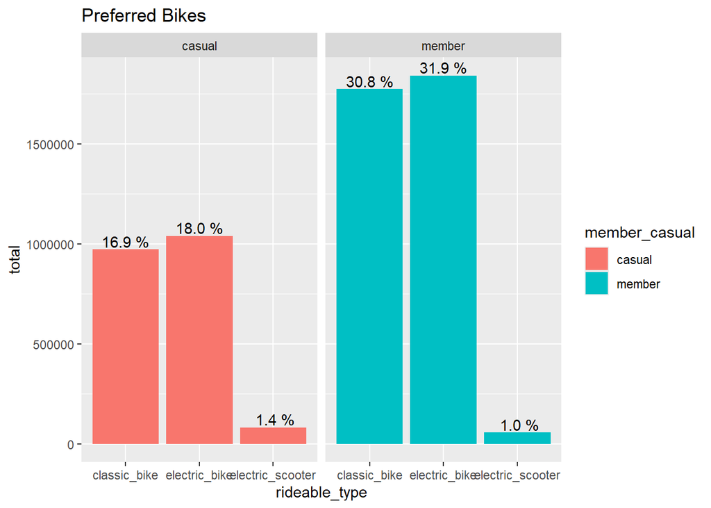

```r
bike_Final_clean %>%
  group_by(member_casual, rideable_type) %>%
  summarise(total=n(), .groups = 'drop', perc =round(n()/nrow(bike_Final_clean)*100, 1)) %>%
  arrange(rideable_type) %>%
  ggplot(aes(x=rideable_type, y= total, fill=member_casual))+
  geom_col(position='dodge')+
  labs(title = "Preferred Bikes")+
  facet_wrap(~member_casual)+
  geom_text(aes(label = paste(format(perc, nsmall=1), "%")), vjust= -0.2)
```

#Of all the total bike usage, electric bike is the most preferred by both members and causal riders with % of 31.9 and 18.0 respectively. Its also observed that members usage of classic bike is also relatively higher while the use of electric scooter for both members and causal is marginal with 1.0% and 1.4% respectively.

#Share

#Recommendation #Conduct a survey to know why electric scooter is not regularly used by both the members and casuals. From what I know electric scooter moves faster than the rest of the 2 others. #Your findings will help you structure your promotion and advertisment to get the targeted clients.